# W3cubDocs

/Matplotlib 3.1

# mpl_toolkits.mplot3d.axes3d.Axes3D

**`class mpl_toolkits.mplot3d.axes3d.Axes3D(fig, rect=None, *args, azim=-60, elev=30, zscale=None, sharez=None, proj_type='persp', **kwargs)` [[source]](https://matplotlib.org/3.1.1/_modules/mpl_toolkits/mplot3d/axes3d.html#Axes3D)**

Bases: `matplotlib.axes._axes.Axes`

3D axes object.

Parameters:

**`fig : Figure`**

The parent figure.

**`rect : (float, float, float, float)`**

The `(left, bottom, width, height)` axes position.

**`azim : float, optional`**

Azimuthal viewing angle, defaults to -60.

**`elev : float, optional`**

Elevation viewing angle, defaults to 30.

**`zscale : ['function' | 'functionlog' | 'linear' | 'log' | 'logit' | 'symlog'], optional`**

The z scale. Note that currently, only a linear scale is supported.

**`sharez : Axes3D, optional`**

Other axes to share z-limits with.

**`proj_type : {'persp', 'ortho'}`**

The projection type, default 'persp'.

#### Notes

New in version 1.2.1: The *sharez* parameter.

**`add_collection3d(self, col, zs=0, zdir='z')` [[source]](https://matplotlib.org/3.1.1/_modules/mpl_toolkits/mplot3d/axes3d.html#Axes3D.add_collection3d)**

Add a 3D collection object to the plot.

2D collection types are converted to a 3D version by modifying the object and adding z coordinate information.

**Supported are:**

- PolyCollection
- LineCollection
- PatchCollection

**`add_contour_set(self, cset, extend3d=False, stride=5, zdir='z', offset=None)` [[source]](https://matplotlib.org/3.1.1/_modules/mpl_toolkits/mplot3d/axes3d.html#Axes3D.add_contour_set)**

**`add_contourf_set(self, cset, zdir='z', offset=None)` [[source]](https://matplotlib.org/3.1.1/_modules/mpl_toolkits/mplot3d/axes3d.html#Axes3D.add_contourf_set)**

**`auto_scale_xyz(self, X, Y, Z=None, had_data=None)` [[source]](https://matplotlib.org/3.1.1/_modules/mpl_toolkits/mplot3d/axes3d.html#Axes3D.auto_scale_xyz)**

**`autoscale(self, enable=True, axis='both', tight=None)` [[source]](https://matplotlib.org/3.1.1/_modules/mpl_toolkits/mplot3d/axes3d.html#Axes3D.autoscale)**

Convenience method for simple axis view autoscaling. See `matplotlib.axes.Axes.autoscale()` for full explanation. Note that this function behaves the same, but for all three axes. Therefore, 'z' can be passed for *axis*, and 'both' applies to all three axes.

New in version 1.1.0: This function was added, but not tested. Please report any bugs.

**`autoscale_view(self, tight=None, scalex=True, scaley=True, scalez=True)` [[source]](https://matplotlib.org/3.1.1/_modules/mpl_toolkits/mplot3d/axes3d.html#Axes3D.autoscale_view)**

Autoscale the view limits using the data limits. See `matplotlib.axes.Axes.autoscale_view()` for documentation. Note that this function applies to the 3D axes, and as such adds the *scalez* to the function arguments.

Changed in version 1.1.0: Function signature was changed to better match the 2D version. *tight* is now explicitly a kwarg and placed first.

Changed in version 1.2.1: This is now fully functional.

**`bar(self, left, height, zs=0, zdir='z', *args, **kwargs)` [[source]](https://matplotlib.org/3.1.1/_modules/mpl_toolkits/mplot3d/axes3d.html#Axes3D.bar)**

Add 2D bar(s).

[output not shown]

**`bar3d(self, x, y, z, dx, dy, dz, color=None, zsort='average', shade=True, *args, **kwargs)` [[source]](https://matplotlib.org/3.1.1/_modules/mpl_toolkits/mplot3d/axes3d.html#Axes3D.bar3d)**

Generate a 3D barplot.

This method creates three dimensional barplot where the width, depth, height, and color of the bars can all be uniquely set.

Parameters:

**`x, y, z : array-like`**

The coordinates of the anchor point of the bars.

**`dx, dy, dz : scalar or array-like`**

The width, depth, and height of the bars, respectively.

**`color : sequence of valid color specifications, optional`**

The color of the bars can be specified globally or individually. This parameter can be:

- A single color value, to color all bars the same color.
- An array of colors of length N bars, to color each bar independently.
- An array of colors of length 6, to color the faces of the bars similarly.
- An array of colors of length 6 * N bars, to color each face independently.

When coloring the faces of the boxes specifically, this is the order of the coloring:

1. -Z (bottom of box)
2. +Z (top of box)
3. -Y
4. +Y
5. -X
6. +X

**`zsort : str, optional`**

The z-axis sorting scheme passed onto `Poly3DCollection`

**`shade : bool, optional (default = True)`**

When true, this shades the dark sides of the bars (relative to the plot's source of light).

**kwargs**

Any additional keyword arguments are passed onto `Poly3DCollection`.

Returns:

**`collection : Poly3DCollection`**

A collection of three dimensional polygons representing the bars.

**`can_pan(self)` [[source]](https://matplotlib.org/3.1.1/_modules/mpl_toolkits/mplot3d/axes3d.html#Axes3D.can_pan)**

Return *True* if this axes supports the pan/zoom button functionality.

3D axes objects do not use the pan/zoom button.

**`can_zoom(self)` [[source]](https://matplotlib.org/3.1.1/_modules/mpl_toolkits/mplot3d/axes3d.html#Axes3D.can_zoom)**

Return *True* if this axes supports the zoom box button functionality.

3D axes objects do not use the zoom box button.

**`cla(self)` [[source]](https://matplotlib.org/3.1.1/_modules/mpl_toolkits/mplot3d/axes3d.html#Axes3D.cla)**

Clear axes

**`clabel(self, *args, **kwargs)` [[source]](https://matplotlib.org/3.1.1/_modules/mpl_toolkits/mplot3d/axes3d.html#Axes3D.clabel)**

This function is currently not implemented for 3D axes. Returns *None*.

**`contour(self, X, Y, Z, *args, extend3d=False, stride=5, zdir='z', offset=None, **kwargs)` [[source]](https://matplotlib.org/3.1.1/_modules/mpl_toolkits/mplot3d/axes3d.html#Axes3D.contour)**

Create a 3D contour plot.

[output not shown]

**`contour3D(self, X, Y, Z, *args, extend3d=False, stride=5, zdir='z', offset=None, **kwargs)`**

Create a 3D contour plot.

[output not shown]

**`contourf(self, X, Y, Z, *args, zdir='z', offset=None, **kwargs)` [[source]](https://matplotlib.org/3.1.1/_modules/mpl_toolkits/mplot3d/axes3d.html#Axes3D.contourf)**

Create a 3D filled contour plot.

[output not shown]

#### Notes

New in version 1.1.0: The *zdir* and *offset* parameters.

**`contourf3D(self, X, Y, Z, *args, zdir='z', offset=None, **kwargs)`**

Create a 3D filled contour plot.

[output not shown]

#### Notes

New in version 1.1.0: The *zdir* and *offset* parameters.

**`convert_zunits(self, z)` [[source]](https://matplotlib.org/3.1.1/_modules/mpl_toolkits/mplot3d/axes3d.html#Axes3D.convert_zunits)**

For artists in an axes, if the zaxis has units support, convert *z* using zaxis unit type

New in version 1.2.1.

**`disable_mouse_rotation(self)` [[source]](https://matplotlib.org/3.1.1/_modules/mpl_toolkits/mplot3d/axes3d.html#Axes3D.disable_mouse_rotation)**

Disable mouse button callbacks.

**`draw(self, renderer)` [[source]](https://matplotlib.org/3.1.1/_modules/mpl_toolkits/mplot3d/axes3d.html#Axes3D.draw)**

Draw everything (plot lines, axes, labels)

**`format_coord(self, xd, yd)` [[source]](https://matplotlib.org/3.1.1/_modules/mpl_toolkits/mplot3d/axes3d.html#Axes3D.format_coord)**

Given the 2D view coordinates attempt to guess a 3D coordinate. Looks for the nearest edge to the point and then assumes that the point is at the same z location as the nearest point on the edge.

**`format_zdata(self, z)` [[source]](https://matplotlib.org/3.1.1/_modules/mpl_toolkits/mplot3d/axes3d.html#Axes3D.format_zdata)**

Return *z* string formatted. This function will use the `fmt_zdata` attribute if it is callable, else will fall back on the zaxis major formatter

**`get_autoscale_on(self)` [[source]](https://matplotlib.org/3.1.1/_modules/mpl_toolkits/mplot3d/axes3d.html#Axes3D.get_autoscale_on)**

Get whether autoscaling is applied for all axes on plot commands

New in version 1.1.0: This function was added, but not tested. Please report any bugs.

**`get_autoscalez_on(self)` [[source]](https://matplotlib.org/3.1.1/_modules/mpl_toolkits/mplot3d/axes3d.html#Axes3D.get_autoscalez_on)**

Get whether autoscaling for the z-axis is applied on plot commands

New in version 1.1.0: This function was added, but not tested. Please report any bugs.

**`get_axis_position(self)` [[source]](https://matplotlib.org/3.1.1/_modules/mpl_toolkits/mplot3d/axes3d.html#Axes3D.get_axis_position)**

**`get_frame_on(self)` [[source]](https://matplotlib.org/3.1.1/_modules/mpl_toolkits/mplot3d/axes3d.html#Axes3D.get_frame_on)**

Get whether the 3D axes panels are drawn.

New in version 1.1.0.

**`get_proj(self)` [[source]](https://matplotlib.org/3.1.1/_modules/mpl_toolkits/mplot3d/axes3d.html#Axes3D.get_proj)**

Create the projection matrix from the current viewing position.

elev stores the elevation angle in the z plane azim stores the azimuth angle in the x,y plane

dist is the distance of the eye viewing point from the object point.

**`get_w_lims(self)` [[source]](https://matplotlib.org/3.1.1/_modules/mpl_toolkits/mplot3d/axes3d.html#Axes3D.get_w_lims)**

Get 3D world limits.

**`get_xlim(self)`**

Return the x-axis view limits.

| Returns: | **`left, right : (float, float)`** The current x-axis limits in data coordinates. |
| --- | --- |

See also

**`set_xlim`**

**`set_xbound, get_xbound`**

**`invert_xaxis, xaxis_inverted`**

#### Notes

The x-axis may be inverted, in which case the *left* value will be greater than the *right* value.

Changed in version 1.1.0: This function now correctly refers to the 3D x-limits

**`get_xlim3d(self)` [[source]](https://matplotlib.org/3.1.1/_modules/mpl_toolkits/mplot3d/axes3d.html#Axes3D.get_xlim3d)**

Return the x-axis view limits.

| Returns: | **`left, right : (float, float)`** The current x-axis limits in data coordinates. |
| --- | --- |

See also

**`set_xlim`**

**`set_xbound, get_xbound`**

**`invert_xaxis, xaxis_inverted`**

#### Notes

The x-axis may be inverted, in which case the *left* value will be greater than the *right* value.

Changed in version 1.1.0: This function now correctly refers to the 3D x-limits

**`get_ylim(self)`**

Return the y-axis view limits.

| Returns: | **`bottom, top : (float, float)`** The current y-axis limits in data coordinates. |
| --- | --- |

See also

**`set_ylim`**

**`set_ybound, get_ybound`**

**`invert_yaxis, yaxis_inverted`**

#### Notes

The y-axis may be inverted, in which case the *bottom* value will be greater than the *top* value.

Changed in version 1.1.0: This function now correctly refers to the 3D y-limits.

**`get_ylim3d(self)` [[source]](https://matplotlib.org/3.1.1/_modules/mpl_toolkits/mplot3d/axes3d.html#Axes3D.get_ylim3d)**

Return the y-axis view limits.

| Returns: | **`bottom, top : (float, float)`** The current y-axis limits in data coordinates. |
| --- | --- |

See also

**`set_ylim`**

**`set_ybound, get_ybound`**

**`invert_yaxis, yaxis_inverted`**

#### Notes

The y-axis may be inverted, in which case the *bottom* value will be greater than the *top* value.

Changed in version 1.1.0: This function now correctly refers to the 3D y-limits.

**`get_zaxis(self)` [[source]](https://matplotlib.org/3.1.1/_modules/mpl_toolkits/mplot3d/axes3d.html#Axes3D.get_zaxis)**

Return the `ZAxis` (`Axis`) instance.

**`get_zbound(self)` [[source]](https://matplotlib.org/3.1.1/_modules/mpl_toolkits/mplot3d/axes3d.html#Axes3D.get_zbound)**

Returns the z-axis numerical bounds where:

```
lowerBound < upperBound
```

New in version 1.1.0: This function was added, but not tested. Please report any bugs.

**`get_zlabel(self)` [[source]](https://matplotlib.org/3.1.1/_modules/mpl_toolkits/mplot3d/axes3d.html#Axes3D.get_zlabel)**

Get the z-label text string.

New in version 1.1.0: This function was added, but not tested. Please report any bugs.

**`get_zlim(self)`**

Get 3D z limits.

**`get_zlim3d(self)` [[source]](https://matplotlib.org/3.1.1/_modules/mpl_toolkits/mplot3d/axes3d.html#Axes3D.get_zlim3d)**

Get 3D z limits.

**`get_zmajorticklabels(self)` [[source]](https://matplotlib.org/3.1.1/_modules/mpl_toolkits/mplot3d/axes3d.html#Axes3D.get_zmajorticklabels)**

Get the ztick labels as a list of Text instances

New in version 1.1.0.

**`get_zminorticklabels(self)` [[source]](https://matplotlib.org/3.1.1/_modules/mpl_toolkits/mplot3d/axes3d.html#Axes3D.get_zminorticklabels)**

Get the ztick labels as a list of Text instances

Note

Minor ticks are not supported. This function was added only for completeness.

New in version 1.1.0.

**`get_zscale(self)` [[source]](https://matplotlib.org/3.1.1/_modules/mpl_toolkits/mplot3d/axes3d.html#Axes3D.get_zscale)**

**`get_zticklabels(self, minor=False)` [[source]](https://matplotlib.org/3.1.1/_modules/mpl_toolkits/mplot3d/axes3d.html#Axes3D.get_zticklabels)**

Get ztick labels as a list of Text instances. See `matplotlib.axes.Axes.get_yticklabels()` for more details.

Note

Minor ticks are not supported.

New in version 1.1.0.

**`get_zticklines(self)` [[source]](https://matplotlib.org/3.1.1/_modules/mpl_toolkits/mplot3d/axes3d.html#Axes3D.get_zticklines)**

Get ztick lines as a list of Line2D instances. Note that this function is provided merely for completeness. These lines are re-calculated as the display changes.

New in version 1.1.0.

**`get_zticks(self, minor=False)` [[source]](https://matplotlib.org/3.1.1/_modules/mpl_toolkits/mplot3d/axes3d.html#Axes3D.get_zticks)**

Return the z ticks as a list of locations See `matplotlib.axes.Axes.get_yticks()` for more details.

Note

Minor ticks are not supported.

New in version 1.1.0.

**`grid(self, b=True, **kwargs)` [[source]](https://matplotlib.org/3.1.1/_modules/mpl_toolkits/mplot3d/axes3d.html#Axes3D.grid)**

Set / unset 3D grid.

Note

Currently, this function does not behave the same as `matplotlib.axes.Axes.grid()`, but it is intended to eventually support that behavior.

Changed in version 1.1.0: This function was changed, but not tested. Please report any bugs.

**`have_units(self)` [[source]](https://matplotlib.org/3.1.1/_modules/mpl_toolkits/mplot3d/axes3d.html#Axes3D.have_units)**

Return *True* if units are set on the *x*, *y*, or *z* axes

**`invert_zaxis(self)` [[source]](https://matplotlib.org/3.1.1/_modules/mpl_toolkits/mplot3d/axes3d.html#Axes3D.invert_zaxis)**

Invert the z-axis.

New in version 1.1.0: This function was added, but not tested. Please report any bugs.

**`locator_params(self, axis='both', tight=None, **kwargs)` [[source]](https://matplotlib.org/3.1.1/_modules/mpl_toolkits/mplot3d/axes3d.html#Axes3D.locator_params)**

Convenience method for controlling tick locators.

See `matplotlib.axes.Axes.locator_params()` for full documentation. Note that this is for Axes3D objects, therefore, setting *axis* to 'both' will result in the parameters being set for all three axes. Also, *axis* can also take a value of 'z' to apply parameters to the z axis.

New in version 1.1.0: This function was added, but not tested. Please report any bugs.

**`margins(self, *margins, x=None, y=None, z=None, tight=True)` [[source]](https://matplotlib.org/3.1.1/_modules/mpl_toolkits/mplot3d/axes3d.html#Axes3D.margins)**

Convenience method to set or retrieve autoscaling margins.

**signatures::**

margins()

returns xmargin, ymargin, zmargin

```
margins(margin)

margins(xmargin, ymargin, zmargin)

margins(x=xmargin, y=ymargin, z=zmargin)

margins(..., tight=False)
```

All forms above set the xmargin, ymargin and zmargin parameters. All keyword parameters are optional. A single positional argument specifies xmargin, ymargin and zmargin. Passing both positional and keyword arguments for xmargin, ymargin, and/or zmargin is invalid.

The *tight* parameter is passed to `autoscale_view()`, which is executed after a margin is changed; the default here is *True*, on the assumption that when margins are specified, no additional padding to match tick marks is usually desired. Setting *tight* to *None* will preserve the previous setting.

Specifying any margin changes only the autoscaling; for example, if *xmargin* is not None, then *xmargin* times the X data interval will be added to each end of that interval before it is used in autoscaling.

New in version 1.1.0: This function was added, but not tested. Please report any bugs.

**`mouse_init(self, rotate_btn=1, zoom_btn=3)` [[source]](https://matplotlib.org/3.1.1/_modules/mpl_toolkits/mplot3d/axes3d.html#Axes3D.mouse_init)**

Initializes mouse button callbacks to enable 3D rotation of the axes. Also optionally sets the mouse buttons for 3D rotation and zooming.

[output not shown]

**`name = '3d'`**

**`plot(self, xs, ys, *args, zdir='z', **kwargs)` [[source]](https://matplotlib.org/3.1.1/_modules/mpl_toolkits/mplot3d/axes3d.html#Axes3D.plot)**

Plot 2D or 3D data.

Parameters:

**`xs : 1D array-like`**

x coordinates of vertices.

**`ys : 1D array-like`**

y coordinates of vertices.

**`zs : scalar or 1D array-like`**

z coordinates of vertices; either one for all points or one for each point.

**`zdir : {'x', 'y', 'z'}`**

When plotting 2D data, the direction to use as z ('x', 'y' or 'z'); defaults to 'z'.

**kwargs**

Other arguments are forwarded to `matplotlib.axes.Axes.plot`.

**`plot3D(self, xs, ys, *args, zdir='z', **kwargs)`**

Plot 2D or 3D data.

Parameters:

**`xs : 1D array-like`**

x coordinates of vertices.

**`ys : 1D array-like`**

y coordinates of vertices.

**`zs : scalar or 1D array-like`**

z coordinates of vertices; either one for all points or one for each point.

**`zdir : {'x', 'y', 'z'}`**

When plotting 2D data, the direction to use as z ('x', 'y' or 'z'); defaults to 'z'.

**kwargs**

Other arguments are forwarded to `matplotlib.axes.Axes.plot`.

**`plot_surface(self, X, Y, Z, *args, norm=None, vmin=None, vmax=None, lightsource=None, **kwargs)` [[source]](https://matplotlib.org/3.1.1/_modules/mpl_toolkits/mplot3d/axes3d.html#Axes3D.plot_surface)**

Create a surface plot.

By default it will be colored in shades of a solid color, but it also supports color mapping by supplying the *cmap* argument.

Note

The *rcount* and *ccount* kwargs, which both default to 50, determine the maximum number of samples used in each direction. If the input data is larger, it will be downsampled (by slicing) to these numbers of points.

Parameters:

**`X, Y, Z : 2d arrays`**

Data values.

**`rcount, ccount : int`**

Maximum number of samples used in each direction. If the input data is larger, it will be downsampled (by slicing) to these numbers of points. Defaults to 50.

New in version 2.0.

**`rstride, cstride : int`**

Downsampling stride in each direction. These arguments are mutually exclusive with *rcount* and *ccount*. If only one of *rstride* or *cstride* is set, the other defaults to 10.

'classic' mode uses a default of `rstride = cstride = 10` instead of the new default of `rcount = ccount = 50`.

**`color : color-like`**

Color of the surface patches.

**`cmap : Colormap`**

Colormap of the surface patches.

**`facecolors : array-like of colors.`**

Colors of each individual patch.

**`norm : Normalize`**

Normalization for the colormap.

**`vmin, vmax : float`**

Bounds for the normalization.

**`shade : bool`**

Whether to shade the facecolors. Defaults to True. Shading is always disabled when `cmap` is specified.

**`lightsource : LightSource`**

The lightsource to use when `shade` is True.

**kwargs**

Other arguments are forwarded to `Poly3DCollection`.

**`plot_trisurf(self, *args, color=None, norm=None, vmin=None, vmax=None, lightsource=None, **kwargs)` [[source]](https://matplotlib.org/3.1.1/_modules/mpl_toolkits/mplot3d/axes3d.html#Axes3D.plot_trisurf)**

Plot a triangulated surface.

The (optional) triangulation can be specified in one of two ways; either:

```
plot_trisurf(triangulation, ...)
```

where triangulation is a `Triangulation` object, or:

```
plot_trisurf(X, Y, ...)
plot_trisurf(X, Y, triangles, ...)
plot_trisurf(X, Y, triangles=triangles, ...)
```

in which case a Triangulation object will be created. See `Triangulation` for a explanation of these possibilities.

The remaining arguments are:

```
plot_trisurf(..., Z)
```

where *Z* is the array of values to contour, one per point in the triangulation.

Parameters:

**`X, Y, Z : array-like`**

Data values as 1D arrays.

**color**

Color of the surface patches.

**cmap**

A colormap for the surface patches.

**`norm : Normalize`**

An instance of Normalize to map values to colors.

**`vmin, vmax : scalar, optional, default: None`**

Minimum and maximum value to map.

**`shade : bool`**

Whether to shade the facecolors. Defaults to True. Shading is always disabled when *cmap* is specified.

**`lightsource : LightSource`**

The lightsource to use when *shade* is True.

**kwargs**

All other arguments are passed on to `Poly3DCollection`

#### Examples

([Source code](https://matplotlib.org/3.1.1/gallery/mplot3d/trisurf3d.py), png, pdf)

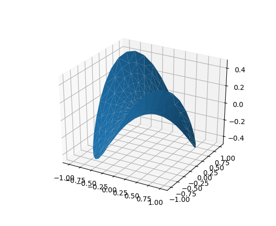

([Source code](https://matplotlib.org/3.1.1/gallery/mplot3d/trisurf3d_2.py), png, pdf)

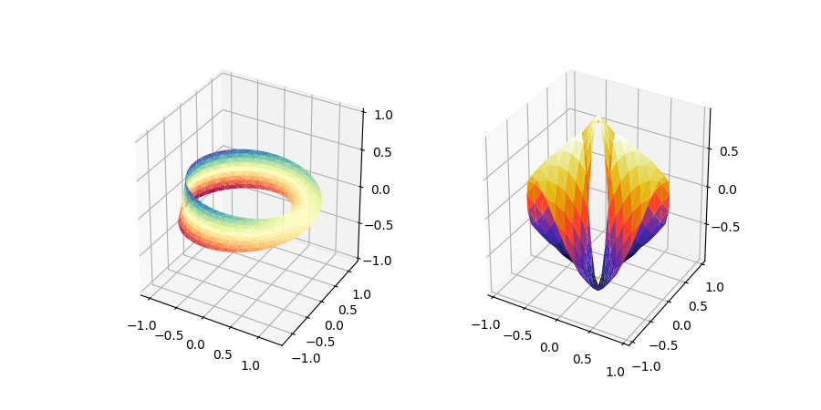

New in version 1.2.0: This plotting function was added for the v1.2.0 release.

**`plot_wireframe(self, X, Y, Z, *args, **kwargs)` [[source]](https://matplotlib.org/3.1.1/_modules/mpl_toolkits/mplot3d/axes3d.html#Axes3D.plot_wireframe)**

Plot a 3D wireframe.

Note

The *rcount* and *ccount* kwargs, which both default to 50, determine the maximum number of samples used in each direction. If the input data is larger, it will be downsampled (by slicing) to these numbers of points.

Parameters:

**`X, Y, Z : 2d arrays`**

Data values.

**`rcount, ccount : int`**

Maximum number of samples used in each direction. If the input data is larger, it will be downsampled (by slicing) to these numbers of points. Setting a count to zero causes the data to be not sampled in the corresponding direction, producing a 3D line plot rather than a wireframe plot. Defaults to 50.

New in version 2.0.

**`rstride, cstride : int`**

Downsampling stride in each direction. These arguments are mutually exclusive with *rcount* and *ccount*. If only one of *rstride* or *cstride* is set, the other defaults to 1. Setting a stride to zero causes the data to be not sampled in the corresponding direction, producing a 3D line plot rather than a wireframe plot.

'classic' mode uses a default of `rstride = cstride = 1` instead of the new default of `rcount = ccount = 50`.

**kwargs**

Other arguments are forwarded to `Line3DCollection`.

**`quiver(X, Y, Z, U, V, W, /, length=1, arrow_length_ratio=.3, pivot='tail', normalize=False, **kwargs)` [[source]](https://matplotlib.org/3.1.1/_modules/mpl_toolkits/mplot3d/axes3d.html#Axes3D.quiver)**

Plot a 3D field of arrows.

The arguments could be array-like or scalars, so long as they they can be broadcast together. The arguments can also be masked arrays. If an element in any of argument is masked, then that corresponding quiver element will not be plotted.

Parameters:

**`X, Y, Z : array-like`**

The x, y and z coordinates of the arrow locations (default is tail of arrow; see *pivot* kwarg)

**`U, V, W : array-like`**

The x, y and z components of the arrow vectors

**`length : float`**

The length of each quiver, default to 1.0, the unit is the same with the axes

**`arrow_length_ratio : float`**

The ratio of the arrow head with respect to the quiver, default to 0.3

**`pivot : {'tail', 'middle', 'tip'}`**

The part of the arrow that is at the grid point; the arrow rotates about this point, hence the name *pivot*. Default is 'tail'

**`normalize : bool`**

When True, all of the arrows will be the same length. This defaults to False, where the arrows will be different lengths depending on the values of u,v,w.

**kwargs**

Any additional keyword arguments are delegated to `LineCollection`

**`quiver3D(X, Y, Z, U, V, W, /, length=1, arrow_length_ratio=.3, pivot='tail', normalize=False, **kwargs)`**

Plot a 3D field of arrows.

The arguments could be array-like or scalars, so long as they they can be broadcast together. The arguments can also be masked arrays. If an element in any of argument is masked, then that corresponding quiver element will not be plotted.

Parameters:

**`X, Y, Z : array-like`**

The x, y and z coordinates of the arrow locations (default is tail of arrow; see *pivot* kwarg)

**`U, V, W : array-like`**

The x, y and z components of the arrow vectors

**`length : float`**

The length of each quiver, default to 1.0, the unit is the same with the axes

**`arrow_length_ratio : float`**

The ratio of the arrow head with respect to the quiver, default to 0.3

**`pivot : {'tail', 'middle', 'tip'}`**

The part of the arrow that is at the grid point; the arrow rotates about this point, hence the name *pivot*. Default is 'tail'

**`normalize : bool`**

When True, all of the arrows will be the same length. This defaults to False, where the arrows will be different lengths depending on the values of u,v,w.

**kwargs**

Any additional keyword arguments are delegated to `LineCollection`

**`scatter(self, xs, ys, zs=0, zdir='z', s=20, c=None, depthshade=True, *args, **kwargs)` [[source]](https://matplotlib.org/3.1.1/_modules/mpl_toolkits/mplot3d/axes3d.html#Axes3D.scatter)**

Create a scatter plot.

Parameters:

**`xs, ys : array-like`**

The data positions.

**`zs : float or array-like, optional, default: 0`**

The z-positions. Either an array of the same length as *xs* and *ys* or a single value to place all points in the same plane.

**`zdir : {'x', 'y', 'z', '-x', '-y', '-z'}, optional, default: 'z'`**

The axis direction for the *zs*. This is useful when plotting 2D data on a 3D Axes. The data must be passed as *xs*, *ys*. Setting *zdir* to 'y' then plots the data to the x-z-plane.

See also [Plot 2D data on 3D plot](https://matplotlib.org/3.1.1/gallery/mplot3d/2dcollections3d.html).

**`s : scalar or array-like, optional, default: 20`**

The marker size in points**2. Either an array of the same length as *xs* and *ys* or a single value to make all markers the same size.

**`c : color, sequence, or sequence of color, optional`**

The marker color. Possible values:

- A single color format string.
- A sequence of color specifications of length n.
- A sequence of n numbers to be mapped to colors using *cmap* and *norm*.
- A 2-D array in which the rows are RGB or RGBA.

For more details see the *c* argument of `scatter`.

**`depthshade : bool, optional, default: True`**

Whether to shade the scatter markers to give the appearance of depth.

**kwargs**

All other arguments are passed on to `scatter`.

Returns:

**`paths : PathCollection`**

**`scatter3D(self, xs, ys, zs=0, zdir='z', s=20, c=None, depthshade=True, *args, **kwargs)`**

Create a scatter plot.

Parameters:

**`xs, ys : array-like`**

The data positions.

**`zs : float or array-like, optional, default: 0`**

The z-positions. Either an array of the same length as *xs* and *ys* or a single value to place all points in the same plane.

**`zdir : {'x', 'y', 'z', '-x', '-y', '-z'}, optional, default: 'z'`**

The axis direction for the *zs*. This is useful when plotting 2D data on a 3D Axes. The data must be passed as *xs*, *ys*. Setting *zdir* to 'y' then plots the data to the x-z-plane.

See also [Plot 2D data on 3D plot](https://matplotlib.org/3.1.1/gallery/mplot3d/2dcollections3d.html).

**`s : scalar or array-like, optional, default: 20`**

The marker size in points**2. Either an array of the same length as *xs* and *ys* or a single value to make all markers the same size.

**`c : color, sequence, or sequence of color, optional`**

The marker color. Possible values:

- A single color format string.
- A sequence of color specifications of length n.
- A sequence of n numbers to be mapped to colors using *cmap* and *norm*.
- A 2-D array in which the rows are RGB or RGBA.

For more details see the *c* argument of `scatter`.

**`depthshade : bool, optional, default: True`**

Whether to shade the scatter markers to give the appearance of depth.

**kwargs**

All other arguments are passed on to `scatter`.

Returns:

**`paths : PathCollection`**

**`set_autoscale_on(self, b)` [[source]](https://matplotlib.org/3.1.1/_modules/mpl_toolkits/mplot3d/axes3d.html#Axes3D.set_autoscale_on)**

Set whether autoscaling is applied on plot commands

New in version 1.1.0: This function was added, but not tested. Please report any bugs.

| Parameters: | **`b : bool`** |
| --- | --- |

**`set_autoscalez_on(self, b)` [[source]](https://matplotlib.org/3.1.1/_modules/mpl_toolkits/mplot3d/axes3d.html#Axes3D.set_autoscalez_on)**

Set whether autoscaling for the z-axis is applied on plot commands

New in version 1.1.0: This function was added, but not tested. Please report any bugs.

| Parameters: | **`b : bool`** |
| --- | --- |

**`set_axis_off(self)` [[source]](https://matplotlib.org/3.1.1/_modules/mpl_toolkits/mplot3d/axes3d.html#Axes3D.set_axis_off)**

Turn the x- and y-axis off.

This affects the axis lines, ticks, ticklabels, grid and axis labels.

**`set_axis_on(self)` [[source]](https://matplotlib.org/3.1.1/_modules/mpl_toolkits/mplot3d/axes3d.html#Axes3D.set_axis_on)**

Turn the x- and y-axis on.

This affects the axis lines, ticks, ticklabels, grid and axis labels.

**`set_frame_on(self, b)` [[source]](https://matplotlib.org/3.1.1/_modules/mpl_toolkits/mplot3d/axes3d.html#Axes3D.set_frame_on)**

Set whether the 3D axes panels are drawn.

New in version 1.1.0.

| Parameters: | **`b : bool`** |
| --- | --- |

**`set_proj_type(self, proj_type)` [[source]](https://matplotlib.org/3.1.1/_modules/mpl_toolkits/mplot3d/axes3d.html#Axes3D.set_proj_type)**

Set the projection type.

| Parameters: | **`proj_type : str`** Type of projection, accepts 'persp' and 'ortho'. |
| --- | --- |

**`set_title(self, label, fontdict=None, loc='center', **kwargs)` [[source]](https://matplotlib.org/3.1.1/_modules/mpl_toolkits/mplot3d/axes3d.html#Axes3D.set_title)**

Set a title for the axes.

Set one of the three available axes titles. The available titles are positioned above the axes in the center, flush with the left edge, and flush with the right edge.

Parameters:

**`label : str`**

Text to use for the title

**`fontdict : dict`**

A dictionary controlling the appearance of the title text, the default `fontdict` is:

```
{'fontsize': rcParams['axes.titlesize'],
 'fontweight' : rcParams['axes.titleweight'],
 'verticalalignment': 'baseline',
 'horizontalalignment': loc}
```

**`loc : {'center', 'left', 'right'}, str, optional`**

Which title to set, defaults to 'center'

**`pad : float`**

The offset of the title from the top of the axes, in points. Default is `None` to use rcParams['axes.titlepad'].

Returns:

**`text : Text`**

The matplotlib text instance representing the title

Other Parameters:

**`**kwargs : Text properties`**

Other keyword arguments are text properties, see `Text` for a list of valid text properties.

**`set_top_view(self)` [[source]](https://matplotlib.org/3.1.1/_modules/mpl_toolkits/mplot3d/axes3d.html#Axes3D.set_top_view)**

**`set_xlim(self, left=None, right=None, emit=True, auto=False, *, xmin=None, xmax=None)`**

Set 3D x limits.

See `matplotlib.axes.Axes.set_xlim()` for full documentation.

**`set_xlim3d(self, left=None, right=None, emit=True, auto=False, *, xmin=None, xmax=None)` [[source]](https://matplotlib.org/3.1.1/_modules/mpl_toolkits/mplot3d/axes3d.html#Axes3D.set_xlim3d)**

Set 3D x limits.

See `matplotlib.axes.Axes.set_xlim()` for full documentation.

**`set_xscale(self, value, **kwargs)` [[source]](https://matplotlib.org/3.1.1/_modules/mpl_toolkits/mplot3d/axes3d.html#Axes3D.set_xscale)**

Set the x-axis scale.

Parameters:

**`value : {"linear", "log", "symlog", "logit", ...}`**

The axis scale type to apply.

**kwargs**

Different keyword arguments are accepted, depending on the scale. See the respective class keyword arguments:

- `matplotlib.scale.LinearScale`
- `matplotlib.scale.LogScale`
- `matplotlib.scale.SymmetricalLogScale`
- `matplotlib.scale.LogitScale`

#### Notes

By default, Matplotlib supports the above mentioned scales. Additionally, custom scales may be registered using `matplotlib.scale.register_scale`. These scales can then also be used here.

New in version 1.1.0: This function was added, but not tested. Please report any bugs.

**`set_ylim(self, bottom=None, top=None, emit=True, auto=False, *, ymin=None, ymax=None)`**

Set 3D y limits.

See `matplotlib.axes.Axes.set_ylim()` for full documentation.

**`set_ylim3d(self, bottom=None, top=None, emit=True, auto=False, *, ymin=None, ymax=None)` [[source]](https://matplotlib.org/3.1.1/_modules/mpl_toolkits/mplot3d/axes3d.html#Axes3D.set_ylim3d)**

Set 3D y limits.

See `matplotlib.axes.Axes.set_ylim()` for full documentation.

**`set_yscale(self, value, **kwargs)` [[source]](https://matplotlib.org/3.1.1/_modules/mpl_toolkits/mplot3d/axes3d.html#Axes3D.set_yscale)**

Set the y-axis scale.

Parameters:

**`value : {"linear", "log", "symlog", "logit", ...}`**

The axis scale type to apply.

**kwargs**

Different keyword arguments are accepted, depending on the scale. See the respective class keyword arguments:

- `matplotlib.scale.LinearScale`
- `matplotlib.scale.LogScale`
- `matplotlib.scale.SymmetricalLogScale`
- `matplotlib.scale.LogitScale`

#### Notes

By default, Matplotlib supports the above mentioned scales. Additionally, custom scales may be registered using `matplotlib.scale.register_scale`. These scales can then also be used here.

New in version 1.1.0: This function was added, but not tested. Please report any bugs.

**`set_zbound(self, lower=None, upper=None)` [[source]](https://matplotlib.org/3.1.1/_modules/mpl_toolkits/mplot3d/axes3d.html#Axes3D.set_zbound)**

Set the lower and upper numerical bounds of the z-axis. This method will honor axes inversion regardless of parameter order. It will not change the `_autoscaleZon` attribute.

New in version 1.1.0: This function was added, but not tested. Please report any bugs.

**`set_zlabel(self, zlabel, fontdict=None, labelpad=None, **kwargs)` [[source]](https://matplotlib.org/3.1.1/_modules/mpl_toolkits/mplot3d/axes3d.html#Axes3D.set_zlabel)**

Set zlabel. See doc for `set_ylabel()` for description.

**`set_zlim(self, bottom=None, top=None, emit=True, auto=False, *, zmin=None, zmax=None)`**

Set 3D z limits.

See `matplotlib.axes.Axes.set_ylim()` for full documentation

**`set_zlim3d(self, bottom=None, top=None, emit=True, auto=False, *, zmin=None, zmax=None)` [[source]](https://matplotlib.org/3.1.1/_modules/mpl_toolkits/mplot3d/axes3d.html#Axes3D.set_zlim3d)**

Set 3D z limits.

See `matplotlib.axes.Axes.set_ylim()` for full documentation

**`set_zmargin(self, m)` [[source]](https://matplotlib.org/3.1.1/_modules/mpl_toolkits/mplot3d/axes3d.html#Axes3D.set_zmargin)**

Set padding of Z data limits prior to autoscaling.

*m* times the data interval will be added to each end of that interval before it is used in autoscaling.

accepts: float in range 0 to 1

New in version 1.1.0: This function was added, but not tested. Please report any bugs.

**`set_zscale(self, value, **kwargs)` [[source]](https://matplotlib.org/3.1.1/_modules/mpl_toolkits/mplot3d/axes3d.html#Axes3D.set_zscale)**

Set the z-axis scale.

Parameters:

**`value : {"linear", "log", "symlog", "logit", ...}`**

The axis scale type to apply.

**kwargs**

Different keyword arguments are accepted, depending on the scale. See the respective class keyword arguments:

- `matplotlib.scale.LinearScale`
- `matplotlib.scale.LogScale`
- `matplotlib.scale.SymmetricalLogScale`
- `matplotlib.scale.LogitScale`

#### Notes

Currently, Axes3D objects only supports linear scales. Other scales may or may not work, and support for these is improving with each release.

By default, Matplotlib supports the above mentioned scales. Additionally, custom scales may be registered using `matplotlib.scale.register_scale`. These scales may then also be used here as support is added.

**`set_zticklabels(self, *args, **kwargs)` [[source]](https://matplotlib.org/3.1.1/_modules/mpl_toolkits/mplot3d/axes3d.html#Axes3D.set_zticklabels)**

Set z-axis tick labels. See `matplotlib.axes.Axes.set_yticklabels()` for more details.

Note

Minor ticks are not supported by Axes3D objects.

New in version 1.1.0.

**`set_zticks(self, *args, **kwargs)` [[source]](https://matplotlib.org/3.1.1/_modules/mpl_toolkits/mplot3d/axes3d.html#Axes3D.set_zticks)**

Set z-axis tick locations. See `matplotlib.axes.Axes.set_yticks()` for more details.

Note

Minor ticks are not supported.

New in version 1.1.0.

**`text(self, x, y, z, s, zdir=None, **kwargs)` [[source]](https://matplotlib.org/3.1.1/_modules/mpl_toolkits/mplot3d/axes3d.html#Axes3D.text)**

Add text to the plot. kwargs will be passed on to Axes.text, except for the `zdir` keyword, which sets the direction to be used as the z direction.

**`text2D(self, x, y, s, fontdict=None, withdash=<deprecated parameter>, **kwargs)`**

Add text to the axes.

Add the text *s* to the axes at location *x*, *y* in data coordinates.

[output not shown]

#### Examples

Individual keyword arguments can be used to override any given parameter:

```
>>> text(x, y, s, fontsize=12)
```

The default transform specifies that text is in data coords, alternatively, you can specify text in axis coords (0,0 is lower-left and 1,1 is upper-right). The example below places text in the center of the axes:

```
>>> text(0.5, 0.5, 'matplotlib', horizontalalignment='center',
...      verticalalignment='center', transform=ax.transAxes)
```

You can put a rectangular box around the text instance (e.g., to set a background color) by using the keyword `bbox`. `bbox` is a dictionary of `Rectangle` properties. For example:

```
>>> text(x, y, s, bbox=dict(facecolor='red', alpha=0.5))
```

**`text3D(self, x, y, z, s, zdir=None, **kwargs)`**

Add text to the plot. kwargs will be passed on to Axes.text, except for the `zdir` keyword, which sets the direction to be used as the z direction.

**`tick_params(self, axis='both', **kwargs)` [[source]](https://matplotlib.org/3.1.1/_modules/mpl_toolkits/mplot3d/axes3d.html#Axes3D.tick_params)**

Convenience method for changing the appearance of ticks and tick labels.

See `matplotlib.axes.Axes.tick_params()` for more complete documentation.

The only difference is that setting *axis* to 'both' will mean that the settings are applied to all three axes. Also, the *axis* parameter also accepts a value of 'z', which would mean to apply to only the z-axis.

Also, because of how Axes3D objects are drawn very differently from regular 2D axes, some of these settings may have ambiguous meaning. For simplicity, the 'z' axis will accept settings as if it was like the 'y' axis.

Note

While this function is currently implemented, the core part of the Axes3D object may ignore some of these settings. Future releases will fix this. Priority will be given to those who file bugs.

New in version 1.1.0: This function was added, but not tested. Please report any bugs.

**`ticklabel_format(self, *, style='', scilimits=None, useOffset=None, axis='both')` [[source]](https://matplotlib.org/3.1.1/_modules/mpl_toolkits/mplot3d/axes3d.html#Axes3D.ticklabel_format)**

Convenience method for manipulating the ScalarFormatter used by default for linear axes in Axed3D objects.

See `matplotlib.axes.Axes.ticklabel_format()` for full documentation. Note that this version applies to all three axes of the Axes3D object. Therefore, the *axis* argument will also accept a value of 'z' and the value of 'both' will apply to all three axes.

New in version 1.1.0: This function was added, but not tested. Please report any bugs.

**`tricontour(self, *args, extend3d=False, stride=5, zdir='z', offset=None, **kwargs)` [[source]](https://matplotlib.org/3.1.1/_modules/mpl_toolkits/mplot3d/axes3d.html#Axes3D.tricontour)**

Create a 3D contour plot.

Changed in version 1.3.0: Added support for custom triangulations

Note

This method currently produces incorrect output due to a longstanding bug in 3D PolyCollection rendering.

[output not shown]

**`tricontourf(self, *args, zdir='z', offset=None, **kwargs)` [[source]](https://matplotlib.org/3.1.1/_modules/mpl_toolkits/mplot3d/axes3d.html#Axes3D.tricontourf)**

Create a 3D filled contour plot.

Note

This method currently produces incorrect output due to a longstanding bug in 3D PolyCollection rendering.

[output not shown]

#### Notes

New in version 1.1.0: The *zdir* and *offset* parameters.

Changed in version 1.3.0: Added support for custom triangulations

**`tunit_cube(self, vals=None, M=None)` [[source]](https://matplotlib.org/3.1.1/_modules/mpl_toolkits/mplot3d/axes3d.html#Axes3D.tunit_cube)**

**`tunit_edges(self, vals=None, M=None)` [[source]](https://matplotlib.org/3.1.1/_modules/mpl_toolkits/mplot3d/axes3d.html#Axes3D.tunit_edges)**

**`unit_cube(self, vals=None)` [[source]](https://matplotlib.org/3.1.1/_modules/mpl_toolkits/mplot3d/axes3d.html#Axes3D.unit_cube)**

**`update_datalim(self, xys, **kwargs)` [[source]](https://matplotlib.org/3.1.1/_modules/mpl_toolkits/mplot3d/axes3d.html#Axes3D.update_datalim)**

Extend the `dataLim` BBox to include the given points.

If no data is set currently, the BBox will ignore its limits and set the bound to be the bounds of the xydata (*xys*). Otherwise, it will compute the bounds of the union of its current data and the data in *xys*.

[output not shown]

**`view_init(self, elev=None, azim=None)` [[source]](https://matplotlib.org/3.1.1/_modules/mpl_toolkits/mplot3d/axes3d.html#Axes3D.view_init)**

Set the elevation and azimuth of the axes in degrees (not radians).

This can be used to rotate the axes programmatically.

'elev' stores the elevation angle in the z plane (in degrees). 'azim' stores the azimuth angle in the x,y plane (in degrees).

if elev or azim are None (default), then the initial value is used which was specified in the `Axes3D` constructor.

**`voxels([x, y, z, ]/, filled, facecolors=None, edgecolors=None, **kwargs)` [[source]](https://matplotlib.org/3.1.1/_modules/mpl_toolkits/mplot3d/axes3d.html#Axes3D.voxels)**

Plot a set of filled voxels

All voxels are plotted as 1x1x1 cubes on the axis, with filled[0,0,0] placed with its lower corner at the origin. Occluded faces are not plotted.

New in version 2.1.

Parameters:

**`filled : 3D np.array of bool`**

A 3d array of values, with truthy values indicating which voxels to fill

**`x, y, z : 3D np.array, optional`**

The coordinates of the corners of the voxels. This should broadcast to a shape one larger in every dimension than the shape of `filled`. These can be used to plot non-cubic voxels.

If not specified, defaults to increasing integers along each axis, like those returned by [`indices()`](https://docs.scipy.org/doc/numpy/reference/generated/numpy.indices.html#numpy.indices). As indicated by the `/` in the function signature, these arguments can only be passed positionally.

**`facecolors, edgecolors : array_like, optional`**

The color to draw the faces and edges of the voxels. Can only be passed as keyword arguments. This parameter can be:

- A single color value, to color all voxels the same color. This can be either a string, or a 1D rgb/rgba array
- `None`, the default, to use a single color for the faces, and the style default for the edges.
- A 3D ndarray of color names, with each item the color for the corresponding voxel. The size must match the voxels.
- A 4D ndarray of rgb/rgba data, with the components along the last axis.

**`shade : bool`**

Whether to shade the facecolors. Defaults to True. Shading is always disabled when *cmap* is specified.

New in version 3.1.

**`lightsource : LightSource`**

The lightsource to use when *shade* is True.

New in version 3.1.

**kwargs**

Additional keyword arguments to pass onto `Poly3DCollection()`

Returns:

**`faces : dict`**

A dictionary indexed by coordinate, where `faces[i,j,k]` is a `Poly3DCollection` of the faces drawn for the voxel `filled[i,j,k]`. If no faces were drawn for a given voxel, either because it was not asked to be drawn, or it is fully occluded, then `(i,j,k) not in faces`.

#### Examples

([Source code](https://matplotlib.org/3.1.1/gallery/mplot3d/voxels.py), png, pdf)

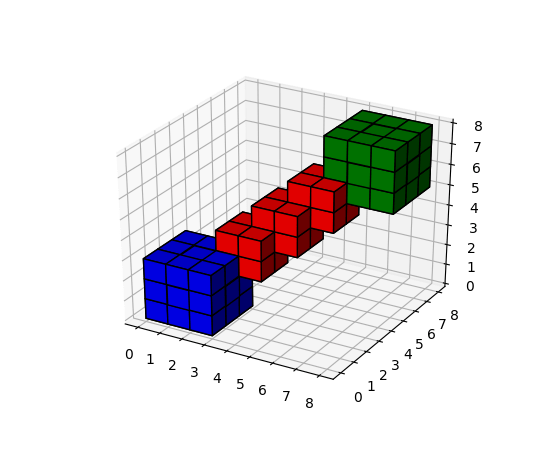

([Source code](https://matplotlib.org/3.1.1/gallery/mplot3d/voxels_rgb.py), png, pdf)

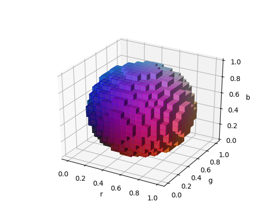

([Source code](https://matplotlib.org/3.1.1/gallery/mplot3d/voxels_torus.py), png, pdf)

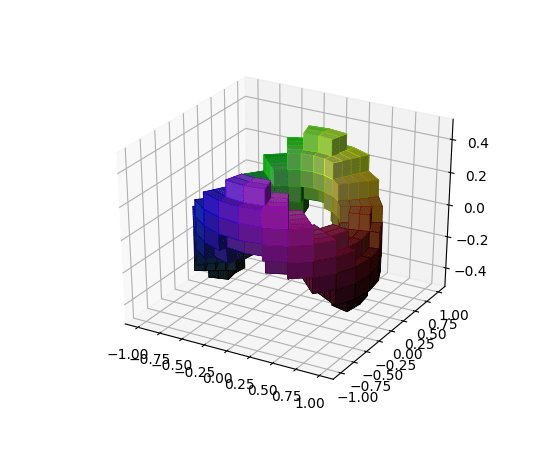

([Source code](https://matplotlib.org/3.1.1/gallery/mplot3d/voxels_numpy_logo.py), png, pdf)

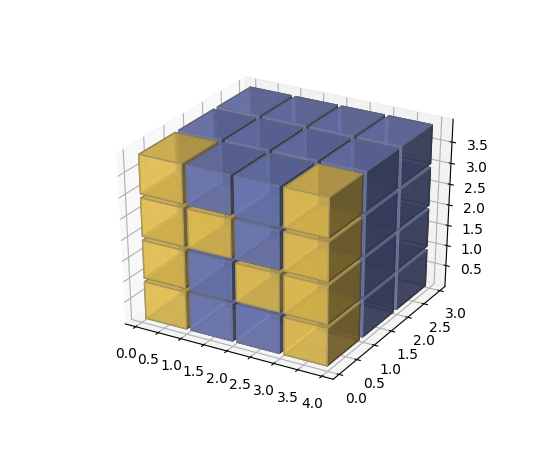

**`zaxis_date(self, tz=None)` [[source]](https://matplotlib.org/3.1.1/_modules/mpl_toolkits/mplot3d/axes3d.html#Axes3D.zaxis_date)**

Sets up z-axis ticks and labels that treat the z data as dates.

*tz* is a timezone string or `tzinfo` instance. Defaults to rc value.

Note

This function is merely provided for completeness. Axes3D objects do not officially support dates for ticks, and so this may or may not work as expected.

New in version 1.1.0: This function was added, but not tested. Please report any bugs.

**`zaxis_inverted(self)` [[source]](https://matplotlib.org/3.1.1/_modules/mpl_toolkits/mplot3d/axes3d.html#Axes3D.zaxis_inverted)**

Returns True if the z-axis is inverted.

New in version 1.1.0: This function was added, but not tested. Please report any bugs.

© 2012–2018 Matplotlib Development Team. All rights reserved.  
Licensed under the Matplotlib License Agreement.  
https://matplotlib.org/3.1.1/api/_as_gen/mpl_toolkits.mplot3d.axes3d.Axes3D.html